# PSTAT 131 Final Project: Stroke Prediction - Binary Classification

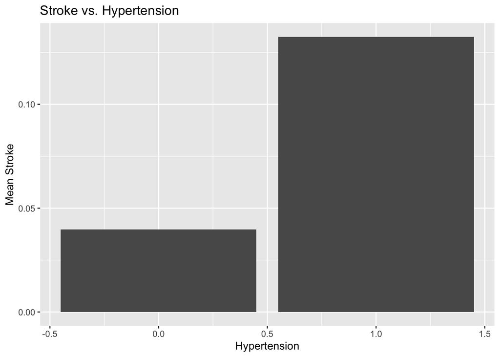

```r
ggplot(stroke_data, aes(x=hypertension,y=stroke))+
  geom_bar(stat = "summary", fun = "mean", position = "dodge")+
  labs(title = "Stroke vs. Hypertension",
       x = "Hypertension",
       y = "Mean Stroke")
```

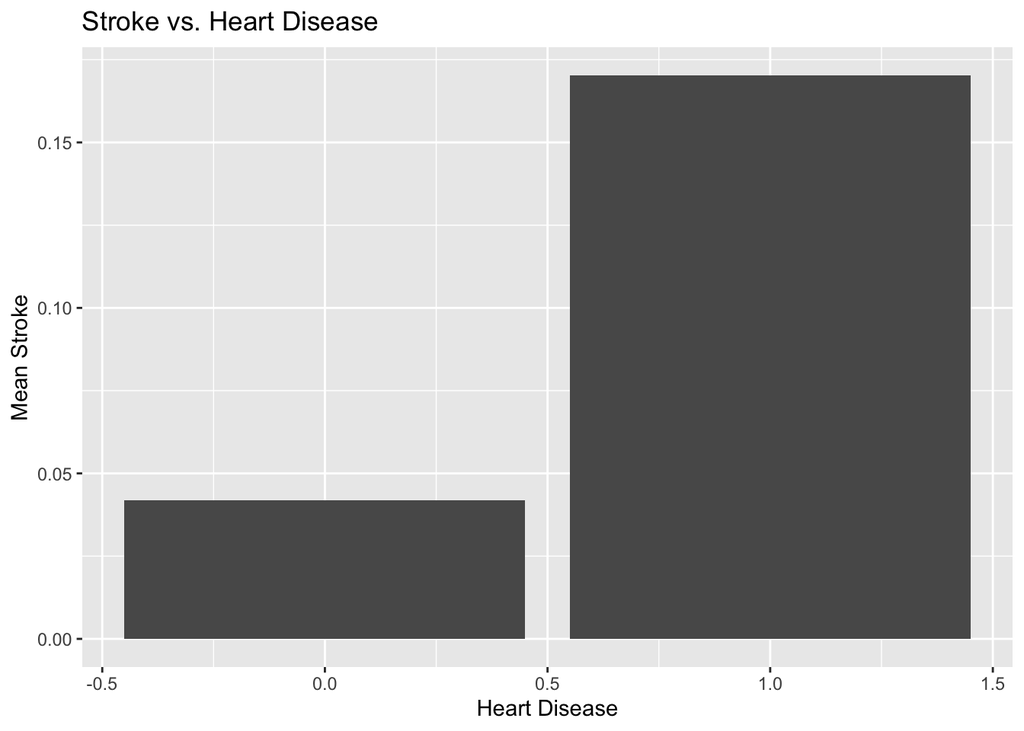

```r
ggplot(stroke_data, aes(x=heart_disease,y=stroke))+
  geom_bar(stat = "summary", fun = "mean", position = "dodge")+
  labs(title = "Stroke vs. Heart Disease",
       x = "Heart Disease",
       y = "Mean Stroke")
```

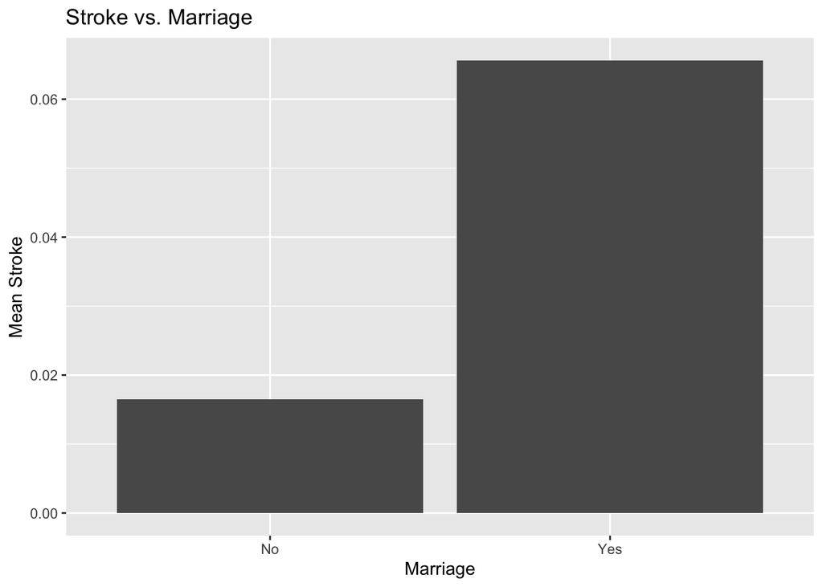

```r
ggplot(stroke_data, aes(x=ever_married,y=stroke))+
  geom_bar(stat = "summary", fun = "mean", position = "dodge")+
  labs(title = "Stroke vs. Marriage",
       x = "Marriage",
       y = "Mean Stroke")
```

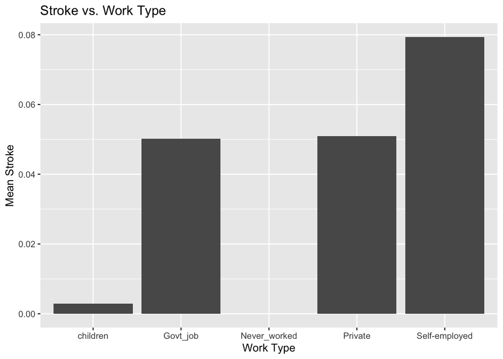

```r
ggplot(stroke_data, aes(x=work_type,y=stroke))+
  geom_bar(stat = "summary", fun = "mean", position = "dodge")+
  labs(title = "Stroke vs. Work Type",
       x = "Work Type",
       y = "Mean Stroke")
```

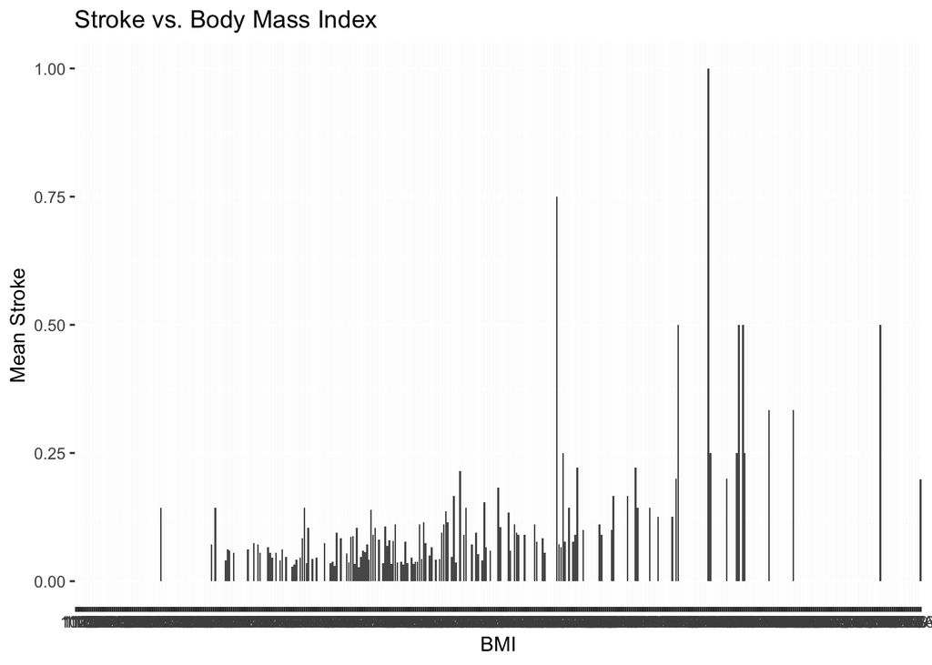

```r
ggplot(stroke_data, aes(x=bmi,y=stroke))+
  geom_bar(stat = "summary", fun = "mean", position = "dodge")+
  labs(title = "Stroke vs. Body Mass Index",
       x = "BMI",
       y = "Mean Stroke")
```

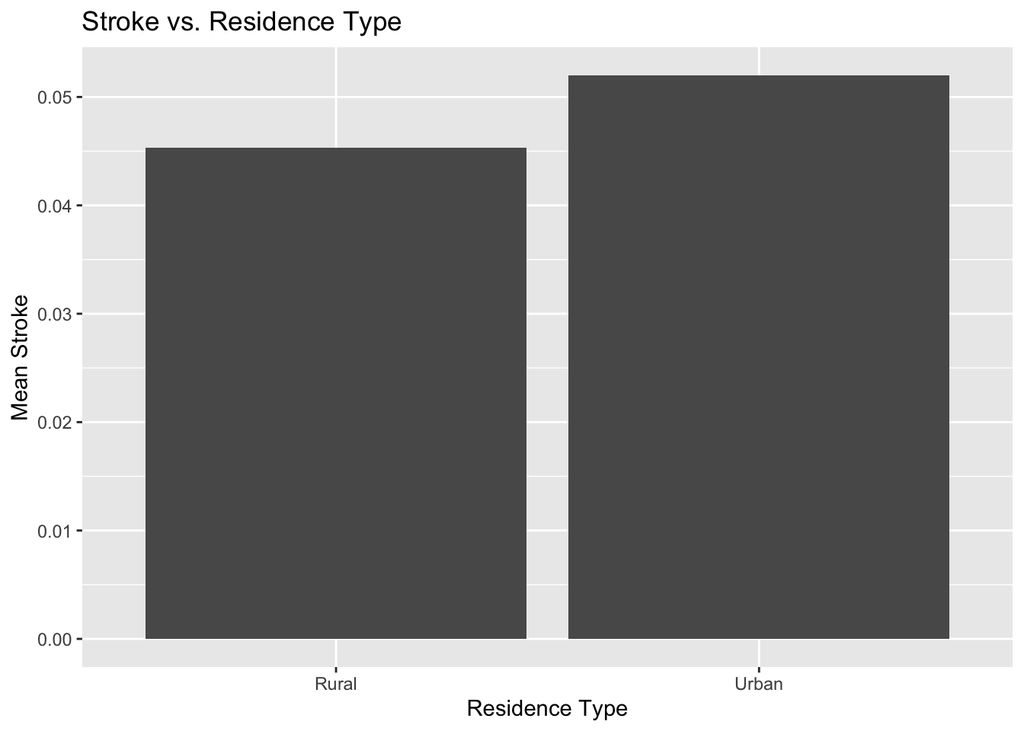

```r
ggplot(stroke_data, aes(x=Residence_type,y=stroke))+
  geom_bar(stat = "summary", fun = "mean", position = "dodge")+
  labs(title = "Stroke vs. Residence Type",
       x = "Residence Type",
       y = "Mean Stroke")
```

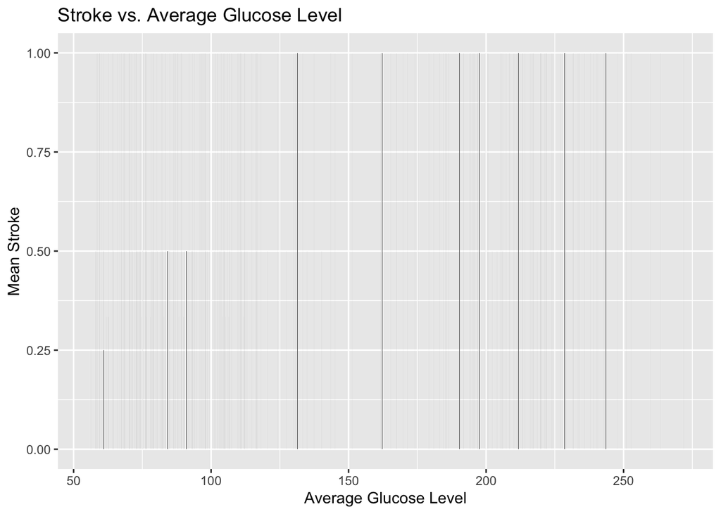

```r
ggplot(stroke_data, aes(x=avg_glucose_level,y=stroke))+
  geom_bar(stat = "summary", fun = "mean", position = "dodge")+
  labs(title = "Stroke vs. Average Glucose Level",
       x = "Average Glucose Level",
       y = "Mean Stroke")
```

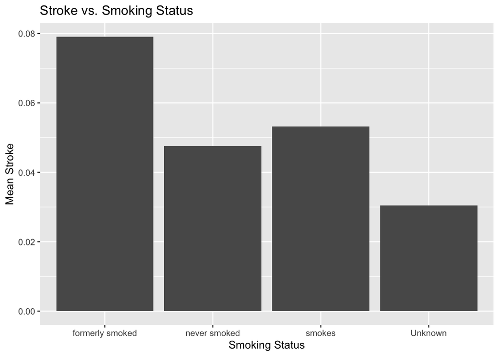

```r
ggplot(stroke_data, aes(x=smoking_status,y=stroke))+
  geom_bar(stat = "summary", fun = "mean", position = "dodge")+
  labs(title = "Stroke vs. Smoking Status",
       x = "Smoking Status",
       y = "Mean Stroke")
```

Viewing the bar plots above we can see that there is very little data on those who have had a stroke compared to those who have not. Since there is no specification on whether the data was randomly selected, we have to take results with caution because the results can potentially be skewed to show a lower stroke prediction than reality.

## Data Cleaning

```r
# Remove NA values
stroke_data_cleaned <- stroke_data %>%

  mutate(smoking_status = ifelse(smoking_status == "Unknown", "N/A", smoking_status)) %>%

  mutate(Residence_type = as.factor(ifelse(Residence_type == "Urban", 1, 0))) %>%

  mutate(ever_married = as.factor(ifelse(ever_married == "Yes", 1, 0))) %>%

  mutate(hypertension = as.factor(hypertension)) %>%

  mutate(heart_disease = as.factor(heart_disease)) %>%

  mutate(stroke = as.factor(stroke)) %>%

  mutate(gender = factor(stroke_data$gender, levels = c("Other", "Male", "Female"), labels = c(0, 1, 2))) %>%

  mutate(smoking_status = factor(stroke_data$smoking_status, levels = c("never smoked", "formerly smoked", "smokes"), labels = c(0, 1, 2))) %>%

  mutate(work_type = factor(stroke_data$work_type, levels = c("children", "Govt_job", "Never_worked", "Private", "Self-employed"), labels = c(0, 1, 2,3,4))) %>%

  mutate(bmi = as.numeric(bmi)) %>%

  filter_all(all_vars(!grepl("N/A", as.character(.)))) %>%

  na.omit(stroke_data)
```

## Train/Test Split

```r
# assign dummy variables to all factors
response <- stroke_data_cleaned$stroke
stroke_data <- model.matrix(~.-1, data = stroke_data_cleaned, response)

# Splitting index, using 80% for training data
set.seed(1)
split_index <- sample(1:nrow(stroke_data), size = 0.8 * nrow(stroke_data))

# assign values at train/test indeces
train <- stroke_data[split_index,]
test <- stroke_data[-split_index,]

x.train <- train[, -ncol(train)]
y.train <- train[, ncol(train)]

x.test <- test[, -ncol(test)]
y.test <- test[, ncol(test)]
```

Let’s first check the prediction accuracy using a non-parametric method, k-NN classification.

## k-NN Classification

```r
# knn - train the classifier and make predictions on the TRAINING set!
pred.YTtrain = knn(train=x.train, test=x.train, cl=y.train, k=2)

# Confusion matrix on training data to get training error rate
conf.train <- table(predicted=pred.YTtrain, true=y.train)
conf.train
```

```
##          true
## predicted    0    1
##         0 2595  139
##         1    0    6
```

The training confusion matrix shows that out of 2595 people who did not have a stroke, the model predicted all 2595 to not have a stroke. However, out of the 145 people who in fact did have a stroke, the model predicted 139 to not have a stroke. The k-NN model was only able to detect 6 stroke positive cases out of the 145 people. This implies that the model’s True Positive Rate is low, because it is classifying only 4.13% of the positive stroke cases correctly. This can be due to the fact mentioned earlier regarding limited amount of stroke-positive data available for the model to correctly learn which factors contribute to having a stroke. Training predictions typically perform better, now let’s apply this model to the test data set to see how well it performs.

```r
# Make predictions on test set
pred.YTest <- knn(train = x.train, test = x.test, cl = y.train, k = 2)

# Get confusion matrix
conf.test <- table(pred.YTest, y.test)
conf.test
```

```
##           y.test
## pred.YTest   0   1
##          0 647  34
##          1   4   1
```

Similar to the predictions on the training set, the k-NN model worked best at correctly classifying the no stroke, and again predicted a large percentage to not have a stroke despite them actually having one. Only one observation that actually had a stroke was correctly classified. Despite the model correctly classifying 99% of observations who did not have a stroke, it was only able to correctly classify 2.8% of those that did have a stroke. This again, may be due to the limited amount of stroke-positive data in the original set to work with.

## Ridge Regression

```r
# find tuning parameter for ridge regression
cvout <- cv.glmnet(x.train, y.train, alpha = 0, family='binomial')
lambda_opt <- cvout$lambda.min

# Ridge Regression
fit <- glmnet(x.train, y.train, family = 'binomial', alpha = 0)
ridge.pred <- predict(fit, s = lambda_opt, newx = x.test, newy = y.test, type = "class")

ridge_coef <- coef(fit, s = lambda_opt)

# Confusion Matrix
conf.ridge <- table(ridge.pred, y.test)
conf.ridge
```

```
##           y.test
## ridge.pred   0   1
##          0 651  35
```

The Ridge regression model use the concept of regularization that apply a shrinkage penalty to each of the beta coefficients, to develop an optimal model. The shrinkage penalty is a combination of a lambda value multiplied by the L2 norm squared. The lambda value is chosen through cross-validation methods, and the fitted regression model is then used to predict the outcome on the testing set. Finally, a confusion matrix is created to evaluate the model’s performance. Since the confusion matrix only has 1 row, implying that there were no predictions for positive-stroke. This suggests that the positive-stroke was not well represented by the data.

## Lasso Regression

```r
# find tuning parameter for ridge regression
cvout <- cv.glmnet(x.train, y.train, alpha = 1, family='binomial')
lambda_opt <- cvout$lambda.min

# Lasso Regression
fit <- glmnet(x.train, y.train, family = 'binomial', alpha = 1)
lasso.pred <- predict(fit, s = lambda_opt, newx = x.test , type = "class")

lasso_coef <- coef(fit, s = lambda_opt)

# Confusion Matrix
conf.lasso <- table(lasso.pred, y.test)
conf.lasso
```

```
##           y.test
## lasso.pred   0   1
##          0 651  35
```

Similar to Ridge regression, Lasso regression is also a regularization technique that uses a shrinkage penalty to modify the beta coefficients and develop an optimal model. This shrinkage penalty is a combination of a chosen lambda value and the L1 norm. Perhaps due to the skewed data, the Ridge and Lasso matrices are leading to the same result.

## ROC/AUC Curve

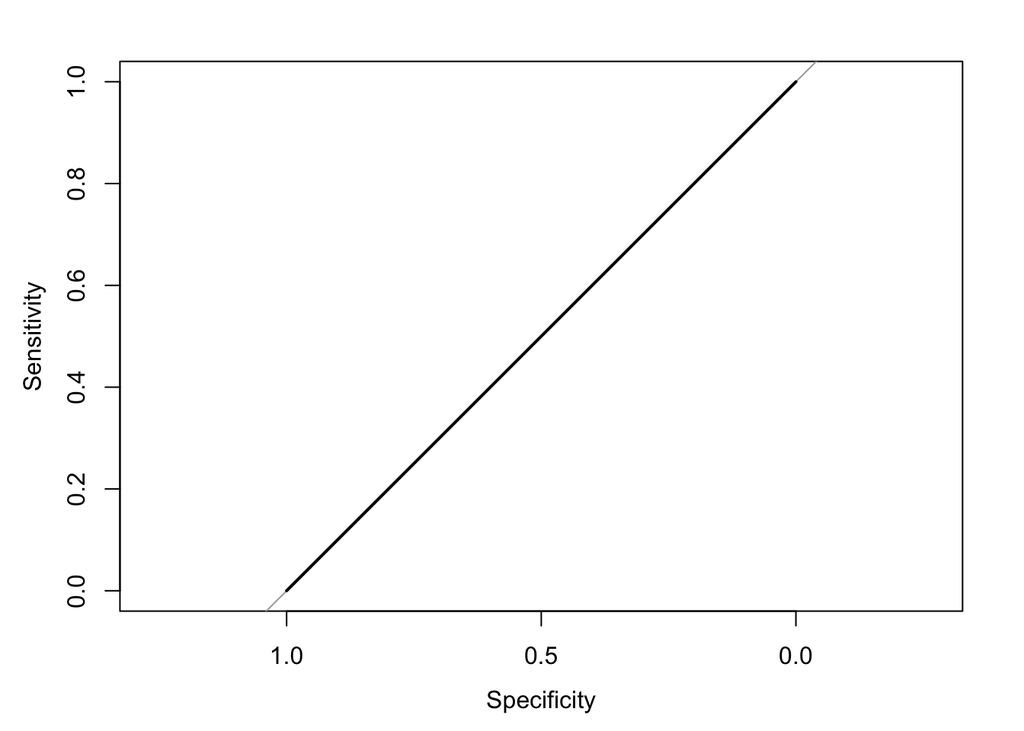

```r
library(pROC)
roc <- roc(y.test, as.numeric(ridge.pred))

plot(roc)
```

```r
auc(roc)
```

```
## Area under the curve: 0.5
```

We can see that even the ROC curve was impacted, resulting in a strange straight line.

The AUC value of 0.5 essentially means the prediction is equivalent to random selection.

Let’s take a different approach using ensemble learning techniques.

## Train/Test Split for Decision Tree and Random Forest

```r
stroke_data <- read.csv("data/stroke_data.csv")

# Splitting index, using 80% for training data
set.seed(4)
split_index <- sample(1:nrow(stroke_data_cleaned), size = 0.8 * nrow(stroke_data_cleaned))

train <- stroke_data_cleaned[split_index,]
test <- stroke_data_cleaned[-split_index,]

x.train <- train[, -ncol(train)]
y.train <- train[, ncol(train)]

x.test <- test[, -ncol(test)]
y.test <- test[, ncol(test)]
```

## Decision Tree

```r
# Creates one tree
stroke_tree <- tree(stroke ~ ., data = train)
print(stroke_tree)
```

```
## node), split, n, deviance, yval, (yprob)
##       * denotes terminal node
##
##  1) root 2740 1105.0 0 ( 0.94891 0.05109 )
##    2) age < 53.5 1595  197.2 0 ( 0.98871 0.01129 )
##      4) age < 37.5 838    0.0 0 ( 1.00000 0.00000 ) *
##      5) age > 37.5 757  170.2 0 ( 0.97622 0.02378 ) *
##    3) age > 53.5 1145  776.9 0 ( 0.89345 0.10655 )
##      6) age < 76.5 911  493.7 0 ( 0.92316 0.07684 )
##       12) avg_glucose_level < 182.945 708  313.2 0 ( 0.94209 0.05791 ) *
##       13) avg_glucose_level > 182.945 203  166.5 0 ( 0.85714 0.14286 ) *
##      7) age > 76.5 234  247.9 0 ( 0.77778 0.22222 ) *
```

```r
summary(stroke_tree)
```

```
##
## Classification tree:
## tree(formula = stroke ~ ., data = train)
## Variables actually used in tree construction:
## [1] "age"               "avg_glucose_level"
## Number of terminal nodes:  5
## Residual mean deviance:  0.3283 = 897.8 / 2735
## Misclassification error rate: 0.05109 = 140 / 2740
```

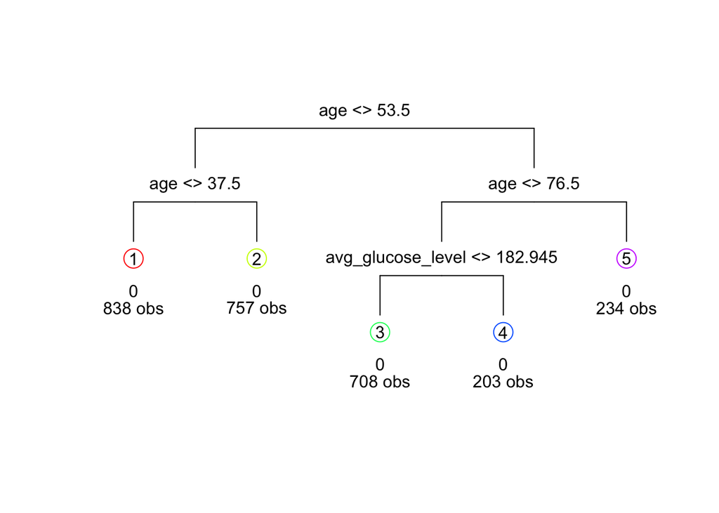

```r
# five fold cross validation tree and shows the best size for the tree (6)
stroke_tree_cv <- cv.tree(stroke_tree, FUN = prune.misclass, K = 5)
best_size <- stroke_tree_cv$size[which.min(stroke_tree_cv$dev)]

#pruned tree
pruned_stroke_tree <- prune.misclass(stroke_tree, best = best_size)
draw.tree(pruned_stroke_tree, nodeinfo = F)
```

```r
#prediction
stroke_tree_predvals <- predict(pruned_stroke_tree, newdata = test, type = "class")
strokeTreeConfusionMat <- table(test$stroke, stroke_tree_predvals)
strokeTreeConfusionMat
```

```
##    stroke_tree_predvals
##       0   1
##   0 646   0
##   1  40   0
```

## Random Forest

```r
# Creates Random Forest
stroke_randomForest <- randomForest(stroke ~ ., data = train, importance = TRUE)
print(stroke_randomForest)
```

```
##
## Call:
##  randomForest(formula = stroke ~ ., data = train, importance = TRUE)
##                Type of random forest: classification
##                      Number of trees: 500
## No. of variables tried at each split: 3
##
##         OOB estimate of  error rate: 5.26%
## Confusion matrix:
##      0 1 class.error
## 0 2596 4 0.001538462
## 1  140 0 1.000000000
```

```r
importance(stroke_randomForest)
```

```
##                            0          1 MeanDecreaseAccuracy MeanDecreaseGini
## id                -1.2274884 -0.1226940           -1.2103733        50.965742
## gender             0.4243524 -0.6550392            0.1165018         6.372579
## age               18.2459806 23.9755682           23.4728700        49.613438
## hypertension       1.5788697  2.4164088            2.2603605         5.451261
## heart_disease     -0.4055853  9.5040118            3.3363136         5.844463
## ever_married      16.0460495 -5.2219287           14.5033693         4.517881
## work_type          6.5182096 -3.4300936            5.1262723         9.929694
## Residence_type     0.6807150 -1.1005913            0.2922909         6.501883
## avg_glucose_level -4.8134270  6.3181930           -2.3699341        55.953719
## bmi                3.9770506 -7.0623812            1.4211396        47.108331
## smoking_status    -0.4539264  0.4607556           -0.2786994        11.075062
```

## Train/Test Split:

```r
# assign dummy variables to all factors
response <- stroke_data_cleaned$stroke
stroke_data <- model.matrix(~.-1, data = stroke_data_cleaned, response)


# Splitting index, using 80% for training data
set.seed(5)
split_index <- sample(1:nrow(stroke_data), size = 0.8 * nrow(stroke_data))

# assign values at train/test indices
train <- stroke_data[split_index,]
test <- stroke_data[-split_index,]

x.train <- train[, -ncol(train)]
y.train <- train[, ncol(train)]

x.test <- test[, -ncol(test)]
y.test <- test[, ncol(test)]
```

Now let us visualize a boosting algorithm.

#GBM

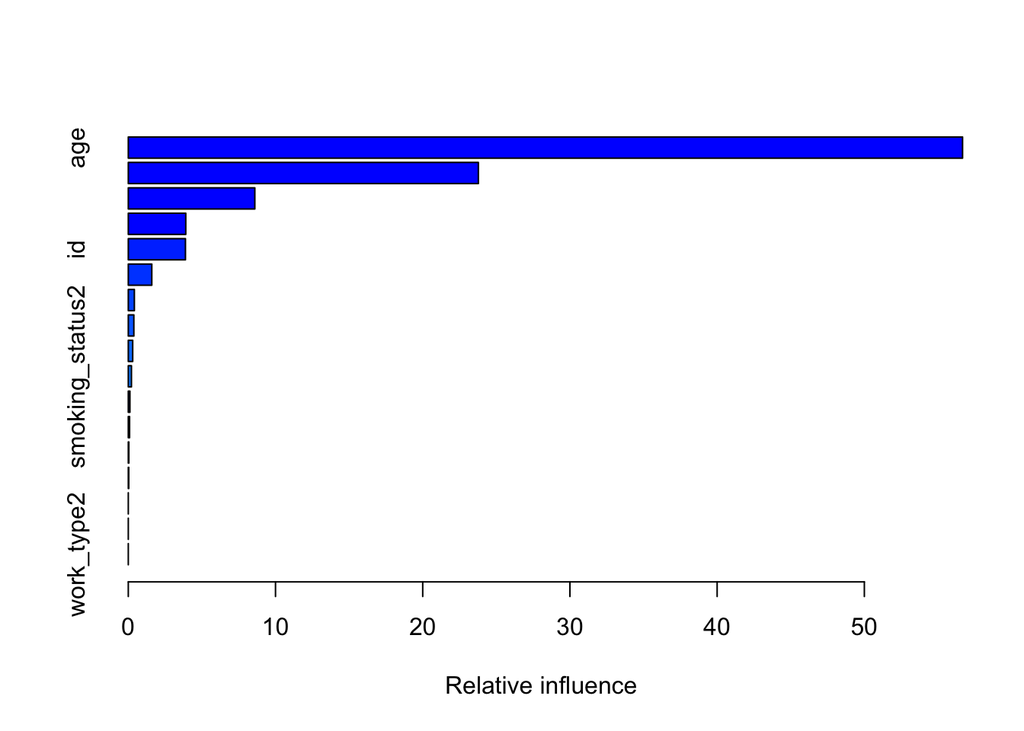

|  | var | rel.inf |
| --- | --- | --- |
| age | age | 56.67145133 |
| avg_glucose_level | avg_glucose_level | 23.77983121 |
| heart_disease1 | heart_disease1 | 8.59610772 |
| hypertension1 | hypertension1 | 3.90475553 |
| id | id | 3.88255941 |
| bmi | bmi | 1.59693689 |
| work_type4 | work_type4 | 0.41215766 |
| smoking_status1 | smoking_status1 | 0.37766598 |
| work_type3 | work_type3 | 0.29999867 |
| smoking_status2 | smoking_status2 | 0.21342163 |

[output cut: 7 more lines]

```r
set.seed(6)

# Generate Boosting Model with 5 cv folds
stroke_gbm <- gbm(stroke1 ~ ., data = as.data.frame(train), distribution = "bernoulli", n.trees = 1000, shrinkage = 0.01, cv.folds = 5)
summary(stroke_gbm)
```

```r
best_trees <- gbm.perf(stroke_gbm, method = "cv")
```

[figure not shown]

```r
stroke_gbm_predvals <- predict(stroke_gbm, newdata = as.data.frame(test), n.trees = best_trees, type = "response")
stroke_gbm_predvals <- ifelse(stroke_gbm_predvals > 0.5, 1, 0)
gbmConfusionMat <- table(y.test, stroke_gbm_predvals)
print(gbmConfusionMat)
```

```
##       stroke_gbm_predvals
## y.test   0
##      0 644
##      1  42
```

The GBM model was trained on the dataset with multiple projections using 1000 trees and a shrinkage of 0.01. The model was validated using five-fold cross-validation to mitigate overfitting and ensure generalizability. The variable importance plot and tables show which predictors are associated with stroke prediction. Age was the most significant predictor and influencer of the relationship, reinforcing the known link between age and stroke. Average blood sugar level is the second most important factor, indicating that patients with high blood sugar have a higher risk of stroke. This pattern was consistent throughout the data analysis. Similarly, the confusion matrix shows a significant true negative rate, indicating skewed data.